# Project 2B: Streaming Data

Zoe, Sally, Dezi

Tuesday, April 12, 2022 @ 05:49 PM

## Setup

### Packages Used

```r
library(tidyverse)
library(dplyr)
library(ggplot2)
library(waffle)
```

### Background of the Data

The datasets were downloaded from [Disney+ Movies and TV Shows | Kaggle](https://www.kaggle.com/datasets/shivamb/disney-movies-and-tv-shows) and [TV shows on Netflix, Prime Video, Hulu and Disney+ | Kaggle](https://www.kaggle.com/datasets/ruchi798/tv-shows-on-netflix-prime-video-hulu-and-disney). You can read about them there, including variable definitions, sources, when they were created, and other information. Load the two datasets and use `glimpse()` to explore their structures.

#### Disney+ Dataset

```r
disney_data <- read_csv("https://raw.githubusercontent.com/STAT-JET-ASU/STT2860S22project2/main/data/disneypluscontent.csv")

glimpse(disney_data)
```

```
Rows: 1,368
Columns: 12
$ show_id      <chr> "s1", "s2", "s3", "s4", "s5", "s6", "s7", "s8", "s9", "s1…
$ type         <chr> "Movie", "Movie", "Movie", "TV Show", "TV Show", "TV Show…
$ title        <chr> "A Spark Story", "Spooky Buddies", "The Fault in Our Star…
$ director     <chr> "Jason Sterman, Leanne Dare", "Robert Vince", "Josh Boone…
$ cast         <chr> "Apthon Corbin, Louis Gonzales", "Tucker Albrizzi, Diedri…
$ country      <chr> NA, "United States, Canada", "United States", "United Sta…
$ date_added   <date> 2021-09-24, 2021-09-24, 2021-09-24, 2021-09-22, 2021-09-…
$ release_year <dbl> 2021, 2011, 2014, 2019, 2021, 2021, 2009, 2021, 2016, 202…
$ rating       <chr> "TV-PG", "G", "PG-13", "TV-PG", "TV-Y", "TV-PG", "PG", "T…
$ duration     <chr> "88 min", "93 min", "127 min", "2 Seasons", "1 Season", "…
$ listed_in    <chr> "Documentary", "Comedy, Fantasy, Kids", "Coming of Age, D…
$ description  <chr> "Two Pixar filmmakers strive to bring their uniquely pers…
```

#### Streaming Dataset

```r
streaming_data <- read_csv("https://raw.githubusercontent.com/STAT-JET-ASU/STT2860S22project2/main/data/streamingcontent.csv")

glimpse(streaming_data)
```

```
Rows: 5,368
Columns: 10
$ ID                <dbl> 1, 2, 3, 4, 5, 6, 7, 8, 9, 10, 11, 12, 13, 14, 15, 1…
$ Title             <chr> "Breaking Bad", "Stranger Things", "Attack on Titan"…
$ Year              <dbl> 2008, 2016, 2013, 2015, 2017, 2005, 2013, 2010, 2011…
$ Age               <chr> "18+", "16+", "18+", "18+", "16+", "7+", "18+", "18+…
$ IMDb              <chr> "9.4/10", "8.7/10", "9.0/10", "8.8/10", "8.8/10", "9…
$ `Rotten Tomatoes` <chr> "100/100", "96/100", "95/100", "94/100", "93/100", "…
$ Netflix           <dbl> 1, 1, 1, 1, 1, 1, 1, 1, 1, 1, 1, 1, 1, 1, 1, 1, 1, 1…
$ Hulu              <dbl> 0, 0, 1, 0, 0, 0, 0, 0, 0, 0, 0, 1, 0, 1, 0, 0, 0, 0…
$ `Prime Video`     <dbl> 0, 0, 0, 0, 0, 1, 0, 0, 0, 0, 0, 1, 0, 1, 0, 0, 0, 0…
$ `Disney+`         <dbl> 0, 0, 0, 0, 0, 0, 0, 0, 0, 0, 0, 0, 0, 0, 0, 0, 0, 0…
```

## Analyses

### Create the Analysis Datasets

#### Dataset #1

The Disney+ dataset contains a variable that gives information about the `rating` for each program offering. Convert the variable into a factor that puts the ratings in (roughly) ascending order of age restriction/audience: `TV-Y`, `TV-Y7`, `TV-Y7-FV`, `TV-G`, `G`, `TV-PG`, `PG`, `PG-13`, `TV-14`. If the `date_added` variable is not already in date format, convert it.

```r
disney_stream <- disney_data %>%
  mutate(rating = factor(rating,
  levels = c("TV-Y", "TV-Y7", "TV-Y7-FV", "TV-G", "G", "TV-PG", "PG", "PG-13", "TV-14")))
```

#### Dataset #2

From the streaming content dataset, create a new dataset by doing the following.

- Use `pivot_longer()` to gather the `Netflix`, `Hulu`, `Prime Video`, and `Disney+` variables into columns called `Service` (containing the name of the streaming service) and `YesNo` (showing the 0/1 indicator values from the original columns).
- After pivoting, filter the dataset to remove any row where `YesNo == 0` (i.e., a show is *not* on the service).
- Split the `IMDb` variable to separate the show rating from the max rating of `10`. Convert the show rating to a numerical variable.
- Split the `Rotten Tomatoes` variable to separate the show rating from the max of `100`. Convert the show rating to a numerical variable.

```r
new_streaming <-  streaming_data %>%
  pivot_longer(cols = 'Netflix':'Disney+',
               names_to = 'Service',
               values_to = 'YesNo') %>%
  filter(YesNo == 1)
 separate(streaming_data, col = IMDb , into = c("ratingIMDb", max = 10), sep = "/")
```

```
# A tibble: 5,368 × 11
      ID Title        Year Age   ratingIMDb `10`  `Rotten Tomato…` Netflix  Hulu
   <dbl> <chr>       <dbl> <chr> <chr>      <chr> <chr>              <dbl> <dbl>
 1     1 Breaking B…  2008 18+   9.4        10    100/100                1     0
 2     2 Stranger T…  2016 16+   8.7        10    96/100                 1     0
 3     3 Attack on …  2013 18+   9.0        10    95/100                 1     1
 4     4 Better Cal…  2015 18+   8.8        10    94/100                 1     0
 5     5 Dark         2017 16+   8.8        10    93/100                 1     0
 6     6 Avatar: Th…  2005 7+    9.3        10    93/100                 1     0
 7     7 Peaky Blin…  2013 18+   8.8        10    93/100                 1     0
 8     8 The Walkin…  2010 18+   8.2        10    93/100                 1     0
 9     9 Black Mirr…  2011 18+   8.8        10    92/100                 1     0
10    10 The Queen'…  2020 18+   8.6        10    92/100                 1     0
# … with 5,358 more rows, and 2 more variables: `Prime Video` <dbl>,
#   `Disney+` <dbl>
```

```r
 separate(streaming_data, col = `Rotten Tomatoes`, into = c("rating`Rotten Tomatoes`", max = 100), sep = "/")
```

```
# A tibble: 5,368 × 11
      ID Title             Year Age   IMDb  `rating\`Rotte…` `100` Netflix  Hulu
   <dbl> <chr>            <dbl> <chr> <chr> <chr>            <chr>   <dbl> <dbl>
 1     1 Breaking Bad      2008 18+   9.4/… 100              100         1     0
 2     2 Stranger Things   2016 16+   8.7/… 96               100         1     0
 3     3 Attack on Titan   2013 18+   9.0/… 95               100         1     1
 4     4 Better Call Saul  2015 18+   8.8/… 94               100         1     0
 5     5 Dark              2017 16+   8.8/… 93               100         1     0
 6     6 Avatar: The Las…  2005 7+    9.3/… 93               100         1     0
 7     7 Peaky Blinders    2013 18+   8.8/… 93               100         1     0
 8     8 The Walking Dead  2010 18+   8.2/… 93               100         1     0
 9     9 Black Mirror      2011 18+   8.8/… 92               100         1     0
10    10 The Queen's Gam…  2020 18+   8.6/… 92               100         1     0
# … with 5,358 more rows, and 2 more variables: `Prime Video` <dbl>,
#   `Disney+` <dbl>
```

### Visualization 1: Violin Plot

**This plot uses Dataset #1.**

Create a violin plot of `release_year` (x-axis) grouped by `type` of program (y-axis) for programs on Disney+. Fill with a color of your choice. Add a boxplot inside the violin plot, as you did in one of the DataCamp exercises. Re-scale the x-axis so that tick marks appear at whole-decade intervals (e.g., 1980, 1990, 2000). Add an appropriate title and axis labels. Use other formatting as you choose to enhance effectiveness/appearance.

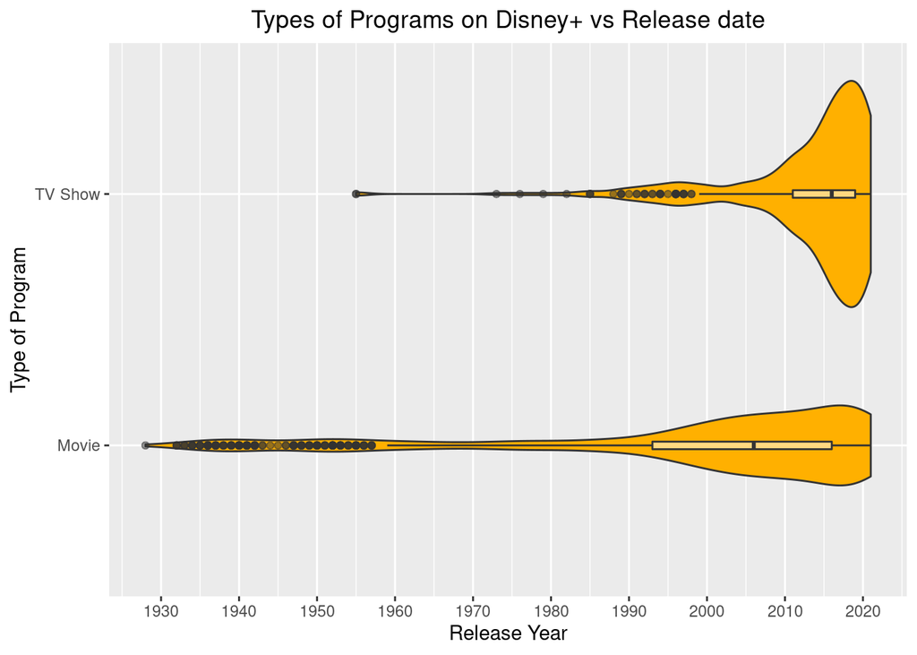

```r
ggplot(disney_data, aes(x = release_year, y = type)) +
  geom_violin(fill = '#ffb000') +
  geom_boxplot(alpha = .5, width = 0.03) +
  scale_x_continuous(breaks = seq(1920, 2030, 10))+
  labs(x = "Release Year", y = "Type of Program",title = "Types of Programs on Disney+ vs Release date")+
    theme(plot.title = element_text(hjust = 0.5))
```

### Visualization 2: Waffle Plot

**This plot uses Dataset #1.**

Create a waffle plot to show the distribution of program `type` on Disney+.

- Give the plot the title “Streaming Content on Disney+”.
- Change the colors of the squares to something other than the defaults.
- Use an x-axis label to indicate roughly how many programs each square represents.

Hint: Use `round(100 * prop.table(table(DATASETNAME$VARIABLENAME)))` to create the input data for the waffle plot. Swap out the capital letter placeholders for the correct dataset name and variable name.

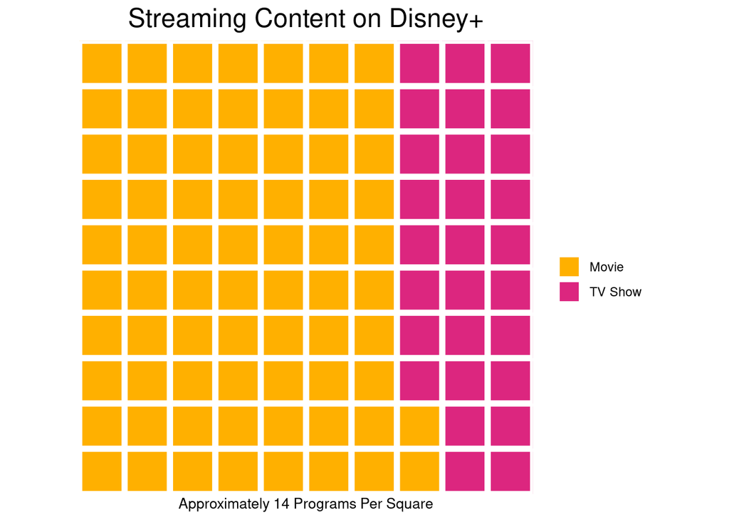

```r
library(waffle)

waffle(round(100 * prop.table(table(disney_data$type))),  x = 'Approximately 14 Programs Per Square', title = 'Streaming Content on Disney+', colors = c('#ffb000','#dc267f'))+
  theme(plot.title = element_text(hjust = 0.5))
```

### Visualization 3: Ratings Bar Plot

**This plot uses Dataset #1.**

Create a horizontal barplot to show the frequencies of the various `rating` categories for programs on Disney+ (i.e., use `y =` rather than `x =` for the variable you are plotting). **You will need to remove a couple `NA` values first.** Facet by `type` so that you have side-by-side plots for the two different program types. Add an appropriate title and axis labels, as well as other formatting to enhance effectiveness/appearance.

```r
disney_data%>%
filter(!is.na(rating))
```

```
# A tibble: 1,366 × 12
   show_id type    title   director cast  country date_added release_year rating
   <chr>   <chr>   <chr>   <chr>    <chr> <chr>   <date>            <dbl> <chr>
 1 s1      Movie   A Spar… Jason S… Apth… <NA>    2021-09-24         2021 TV-PG
 2 s2      Movie   Spooky… Robert … Tuck… United… 2021-09-24         2011 G
 3 s3      Movie   The Fa… Josh Bo… Shai… United… 2021-09-24         2014 PG-13
 4 s4      TV Show Dog: I… <NA>     Matt… United… 2021-09-22         2019 TV-PG
 5 s5      TV Show Spidey… <NA>     Benj… United… 2021-09-22         2021 TV-Y
 6 s6      TV Show Star W… <NA>     <NA>  <NA>    2021-09-22         2021 TV-PG
 7 s7      Movie   Confes… P.J. Ho… Isla… United… 2021-09-17         2009 PG
 8 s8      Movie   Descen… Salvado… Dove… <NA>    2021-09-17         2021 TV-G
 9 s9      Movie   Disney… Jay Hat… John… <NA>    2021-09-17         2016 TV-G
10 s10     Movie   Floode… Katie B… Devi… <NA>    2021-09-17         2021 TV-PG
# … with 1,356 more rows, and 3 more variables: duration <chr>,
#   listed_in <chr>, description <chr>
```

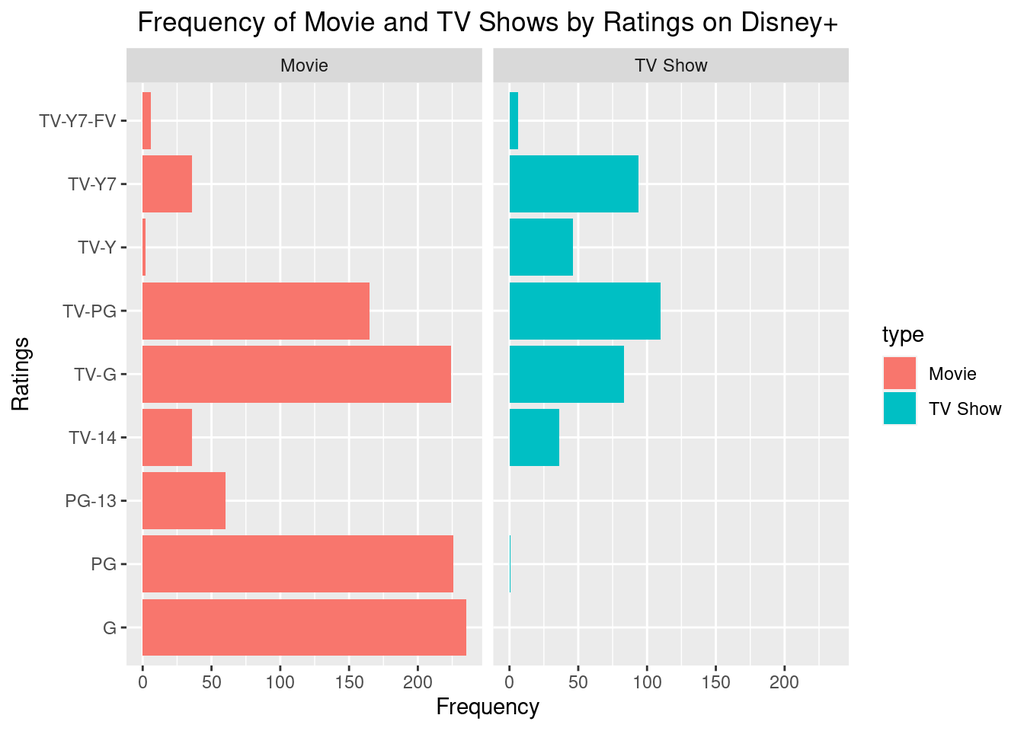

```r
my_table1 <- table(disney_data$rating)
ggplot(data=subset(disney_data, !is.na(rating)), aes(x = frequency(rating), y = rating,fill = type)) +
  geom_col()+
  facet_grid(.~type)+
  labs(x = "Frequency", y = "Ratings", title = "Frequency of Movie and TV Shows by Ratings on Disney+") +
  theme(plot.title = element_text(hjust = 0.5))
```

### Visualization 4: Services Bar Plot

**This plot uses Dataset #2.**

Create a barplot to display how many shows are offered on each of the four streaming services. Choose appropriate colors, labels, themes, and/or and other types of formatting that you feel will enhance the meaning or visual appearance of the plot.

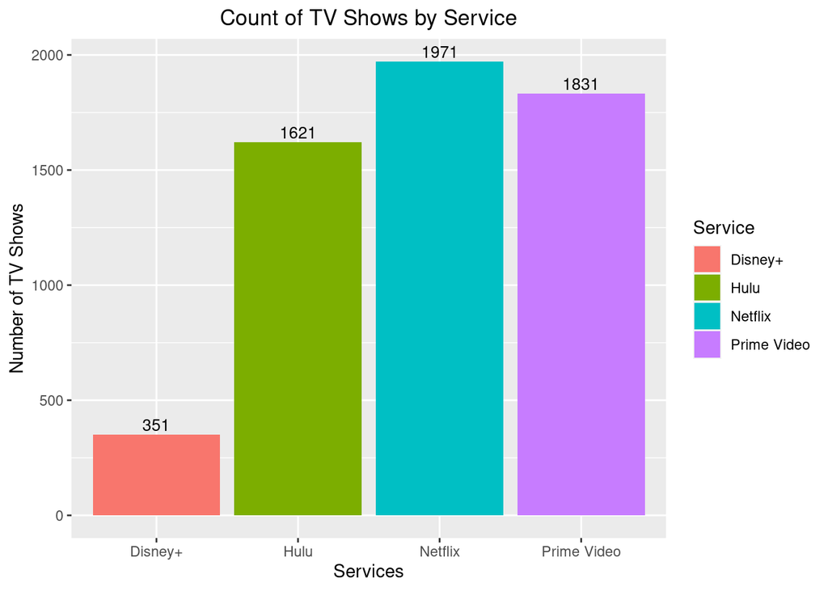

```r
ggplot(new_streaming, aes(x = factor(Service), fill = Service))+
 geom_bar()+
  geom_text(aes(label = ..count..), stat = "count", vjust = -.3, size = 3.5)+

  labs( x = "Services", y = "Number of TV Shows", title = "Count of TV Shows by Service") +
  theme(plot.title = element_text(hjust = 0.5))
```

### Visualization 5: Choose a Plot!

Create one other plot of your choice using either dataset to explore a question of interest. You are welcome to perform additional manipulations on the data, if needed. Add an appropriate title and axis labels, as well as any other necessary formatting.

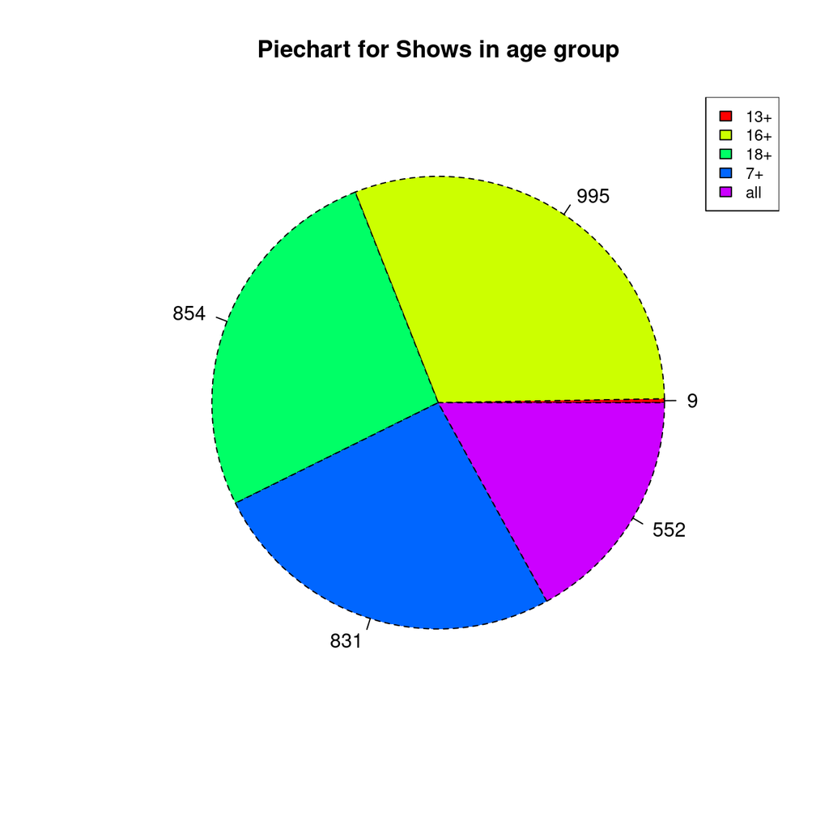

```r
my_table3 <- table(streaming_data$Age)
pie(my_table3, main="Piechart for Shows in age group", col=rainbow(length(my_table3)),labels = my_table3,lty = 2)
legend("topright", c("13+","16+","18+","7+","all"), cex=0.8, fill=rainbow(length(my_table3)))
```

## Questions

**Question 1:** Based on your plots, make five informational statements or comparisons regarding the Disney+ streaming service.

**ANSWER**

**Question 2:** What other data would you like to have, or which existing variables would you like to see transformed if you were going to do further explorations or visualizations? Give at least two examples.

**ANSWER**

I would Like to see all streaming services divided by rating and age group, as well as see the annual volume per age group of people registering for each streaming service.

**Question 3:** Explain the rationale behind the choices you made with regard to plot type, formatting, and so on when you created Visualization 5. What motivated your decisions?

**ANSWER**